# Airbnb_final

Prabhu Shankar

2024-12-12

# Reading data

```r
library(scales)
library(data.table)
library(dplyr)
```

```r
library(ggplot2)
library(RColorBrewer)
library(ggcorrplot)
library(forecast)
# Load dataset
DO_NOT_TOUCH <- read.csv('/Users/prabhushankar/Desktop/Data mining/Project/data_set_1.csv')
```

# NA value check

```r
data_na_check <- DO_NOT_TOUCH

data_na_check$log_price <- log(data_na_check$price)
data_na_check[data_na_check == ""] <- NA

na_counts <- colSums(is.na(data_na_check))
na_percentage <- percent(na_counts / nrow(data_na_check), accuracy = 0.01)
na_summary <- data.frame(Variable = names(na_counts), NA_Counts = na_counts, NA_Percent = na_percentage)

na_summary
```

```
##                                                Variable NA_Counts NA_Percent
## listing_id                                   listing_id         0      0.00%
## name                                               name       172      0.06%
## host_id                                         host_id         0      0.00%
## host_since                                   host_since       165      0.06%
## host_location                             host_location       840      0.30%
## host_response_time                   host_response_time    128782     46.04%
## host_acceptance_rate               host_acceptance_rate    113087     40.43%
## host_is_superhost                     host_is_superhost       165      0.06%
## host_total_listings_count     host_total_listings_count       165      0.06%
## host_has_profile_pic               host_has_profile_pic       165      0.06%
## host_identity_verified           host_identity_verified       165      0.06%
## neighbourhood                             neighbourhood         0      0.00%
## district                                       district    242700     86.77%
## city                                               city         0      0.00%
## latitude                                       latitude         0      0.00%
## longitude                                     longitude         0      0.00%
## property_type                             property_type         0      0.00%
## room_type                                     room_type         0      0.00%
## accommodates                               accommodates         0      0.00%
## bedrooms                                       bedrooms     29435     10.52%
## amenities                                     amenities         0      0.00%
## price                                             price         0      0.00%
## minimum_nights                           minimum_nights         0      0.00%
## maximum_nights                           maximum_nights         0      0.00%
## review_scores_accuracy           review_scores_accuracy     91713     32.79%
## review_scores_cleanliness     review_scores_cleanliness     91665     32.77%
## review_scores_checkin             review_scores_checkin     91771     32.81%
## review_scores_communication review_scores_communication     91687     32.78%
## review_scores_location           review_scores_location     91775     32.81%
## review_scores_value                 review_scores_value     91785     32.81%
## instant_bookable                       instant_bookable         0      0.00%
## log_price                                     log_price         0      0.00%
```

```r
data_na_check <- data_na_check %>%
  mutate(amenities_list = strsplit(amenities, ","), amenities_count = lengths(amenities_list)) %>%
  select(-amenities_list, -amenities)

data_na_check <- data_na_check[, c( "property_type", "room_type",
                 "accommodates", "bedrooms", "price",
                 "instant_bookable", "host_has_profile_pic", "host_identity_verified",
                 "minimum_nights", "maximum_nights","city", "amenities_count", "log_price")]

data_na_check <- na.omit(data_na_check)
```

# A linear regression analysis was conducted using the dataset after omitting entries with missing (NA) values. This approach allowed us to identify significant variables without the influence of incomplete data. The insights from this analysis will guide the imputation process for the missing values, ensuring that only the most impactful variables are considered.

```r
data_na_check <- data_na_check %>%
  mutate(
    room_type = as.factor(room_type),
    instant_bookable = as.factor(instant_bookable),
    host_has_profile_pic = as.factor(host_has_profile_pic),
    host_identity_verified = as.factor(host_identity_verified),
    city = as.factor(city),
  )

summary(linear_model <- lm(log_price ~ . - property_type - price, data_na_check))
```

```
##
## Call:
## lm(formula = log_price ~ . - property_type - price, data = data_na_check)
##
## Residuals:
##     Min      1Q  Median      3Q     Max
## -6.6594 -0.4094 -0.0662  0.3264  8.2497
##
## Coefficients:
##                           Estimate Std. Error  t value Pr(>|t|)
## (Intercept)              6.986e+00  2.444e-02  285.856  < 2e-16 ***
## room_typeHotel room      2.234e-01  9.289e-03   24.049  < 2e-16 ***
## room_typePrivate room   -4.257e-01  3.265e-03 -130.385  < 2e-16 ***
## room_typeShared room    -8.874e-01  9.738e-03  -91.126  < 2e-16 ***
## accommodates             1.322e-01  8.529e-04  154.954  < 2e-16 ***
## bedrooms                 8.924e-02  1.502e-03   59.433  < 2e-16 ***
## instant_bookablet       -1.166e-02  2.769e-03   -4.210 2.56e-05 ***
## host_has_profile_pict   -1.939e-01  2.364e-02   -8.202 2.38e-16 ***
## host_identity_verifiedt -3.806e-02  3.047e-03  -12.491  < 2e-16 ***
## minimum_nights          -8.695e-05  4.188e-05   -2.076   0.0379 *
## maximum_nights          -2.347e-10  2.055e-10   -1.143   0.2532
## cityCape Town           -1.761e-01  7.126e-03  -24.714  < 2e-16 ***
## cityHong Kong           -8.731e-01  1.000e-02  -87.297  < 2e-16 ***
## cityIstanbul            -1.490e+00  6.670e-03 -223.457  < 2e-16 ***
## cityMexico City         -5.271e-01  6.928e-03  -76.088  < 2e-16 ***
## cityNew York            -2.412e+00  6.284e-03 -383.778  < 2e-16 ***
## cityParis               -2.703e+00  5.924e-03 -456.327  < 2e-16 ***
## cityRio de Janeiro      -1.546e+00  6.603e-03 -234.097  < 2e-16 ***
## cityRome                -2.996e+00  6.451e-03 -464.478  < 2e-16 ***
## citySydney              -2.251e+00  6.297e-03 -357.427  < 2e-16 ***
## amenities_count         -2.901e-04  1.515e-04   -1.915   0.0555 .
## ---
## Signif. codes:  0 '***' 0.001 '**' 0.01 '*' 0.05 '.' 0.1 ' ' 1
##
## Residual standard error: 0.6569 on 250111 degrees of freedom
## Multiple R-squared:  0.7353, Adjusted R-squared:  0.7353
## F-statistic: 3.474e+04 on 20 and 250111 DF,  p-value: < 2.2e-16
```

# We are running a Random Forest model to evaluate whether missing (NA) values for key variables can be reliably imputed using regression, based on the relationships between other significant variables in the dataset.

```r
set.seed(123)  # Set seed for reproducibility

# Create a random sample of row indices for the training set
train_indices_random_forest <- sample(1:nrow(data_na_check), size = 0.8 * nrow(data_na_check))

# Split the data
train_set_random_forest <- data_na_check[train_indices_random_forest, ]  # 80%
test_set_random_forest <- data_na_check[-train_indices_random_forest, ]  # 20%
library(randomForest)
model.rf = randomForest(log_price ~ . - price - amenities_count - property_type, data = train_set_random_forest, ntree=50,
nodesize=25, importance = TRUE)




library(caret)
```

[figure not shown]

```r
predict_class.rf_model = predict(model.rf, newdata = test_set_random_forest)
predict_class.rf_model <- factor(predict_class.rf_model)
test_set_random_forest$price <- factor(test_set_random_forest$price)
predict_class.rf_model <- factor(predict_class.rf_model, levels = levels(test_set_random_forest$price))

#confusionMatrix(data = predict_class.rf, reference = test_set$price)
varImpPlot(model.rf, type = 1)
```

Data Cleaning and preprocessing.

```r
data <- DO_NOT_TOUCH[, c("room_type",
                 "accommodates", "bedrooms", "amenities", "price",
                 "instant_bookable", "host_has_profile_pic", "host_identity_verified",
                 "minimum_nights", "maximum_nights","city")]

data$log_price <- log(data$price)
data[data == ""] <- NA

na_counts <- colSums(is.na(data))
na_percentage <- percent(na_counts / nrow(data), accuracy = 0.01)
na_summary <- data.frame(Variable = names(na_counts), NA_Counts = na_counts, NA_Percent = na_percentage)

na_summary
```

```
##                                      Variable NA_Counts NA_Percent
## room_type                           room_type         0      0.00%
## accommodates                     accommodates         0      0.00%
## bedrooms                             bedrooms     29435     10.52%
## amenities                           amenities         0      0.00%
## price                                   price         0      0.00%
## instant_bookable             instant_bookable         0      0.00%
## host_has_profile_pic     host_has_profile_pic       165      0.06%
## host_identity_verified host_identity_verified       165      0.06%
## minimum_nights                 minimum_nights         0      0.00%
## maximum_nights                 maximum_nights         0      0.00%
## city                                     city         0      0.00%
## log_price                           log_price         0      0.00%
```

```r
data$host_has_profile_pic <- ifelse(data$host_has_profile_pic == 'f', "False", "True")

data$instant_bookable <- ifelse(data$instant_bookable == 'f', "False", "True")

data$host_identity_verified <- ifelse(data$host_identity_verified == 'f', "False", "True")



data$bedrooms[is.na(data$bedrooms)] <- 1

cleaned_data <- na.omit(data)


cleaned_data <- cleaned_data %>%
  mutate(amenities_list = strsplit(amenities, ","), amenities_count = lengths(amenities_list)) %>% select(-amenities_list, -amenities)

cleaned_data <- cleaned_data %>%
  filter(log_price > 0, accommodates > 0, bedrooms > 0)
```

# Outlier detection and EDA

```r
# Separate numeric and categorical variables for analysis
numeric_vars <- cleaned_data[, sapply(cleaned_data, is.numeric)]
categorical_vars <- cleaned_data[, !(names(cleaned_data) %in% names(numeric_vars))]
numeric_vars <- subset(numeric_vars)
summary(numeric_vars)
```

```
##   accommodates      bedrooms          price          minimum_nights
##  Min.   : 1.00   Min.   : 1.000   Min.   :     5.0   Min.   :   1.000
##  1st Qu.: 2.00   1st Qu.: 1.000   1st Qu.:    75.0   1st Qu.:   1.000
##  Median : 2.00   Median : 1.000   Median :   150.0   Median :   2.000
##  Mean   : 3.29   Mean   : 1.461   Mean   :   609.1   Mean   :   8.052
##  3rd Qu.: 4.00   3rd Qu.: 2.000   3rd Qu.:   475.0   3rd Qu.:   5.000
##  Max.   :16.00   Max.   :50.000   Max.   :625216.0   Max.   :9999.000
##  maximum_nights        log_price      amenities_count
##  Min.   :1.000e+00   Min.   : 1.609   Min.   : 1.00
##  1st Qu.:4.500e+01   1st Qu.: 4.317   1st Qu.:13.00
##  Median :1.125e+03   Median : 5.011   Median :18.00
##  Mean   :2.759e+04   Mean   : 5.297   Mean   :19.56
##  3rd Qu.:1.125e+03   3rd Qu.: 6.163   3rd Qu.:26.00
##  Max.   :2.147e+09   Max.   :13.346   Max.   :89.00
```

```r
apply(numeric_vars, 2, sd)
```

```
##    accommodates        bedrooms           price  minimum_nights  maximum_nights
##    2.133101e+00    1.102443e+00    3.443465e+03    3.152842e+01    7.286510e+06
##       log_price amenities_count
##    1.269076e+00    9.257260e+00
```

```r
# Calculate interquartile range and variance
apply(numeric_vars, 2, IQR)
```

```
##    accommodates        bedrooms           price  minimum_nights  maximum_nights
##        2.000000        1.000000      400.000000        4.000000     1080.000000
##       log_price amenities_count
##        1.845827       13.000000
```

```r
apply(numeric_vars, 2, var)
```

```
##    accommodates        bedrooms           price  minimum_nights  maximum_nights
##    4.550120e+00    1.215381e+00    1.185745e+07    9.940415e+02    5.309323e+13
##       log_price amenities_count
##    1.610554e+00    8.569687e+01
```

```r
# Generate a correlation matrix for numeric variables
correlation_matrix <- round(cor(numeric_vars), 2)
correlation_matrix
```

```
##                 accommodates bedrooms price minimum_nights maximum_nights
## accommodates            1.00     0.64  0.15          -0.03              0
## bedrooms                0.64     1.00  0.14          -0.01              0
## price                   0.15     0.14  1.00           0.01              0
## minimum_nights         -0.03    -0.01  0.01           1.00              0
## maximum_nights          0.00     0.00  0.00           0.00              1
## log_price               0.36     0.31  0.36          -0.02              0
## amenities_count         0.22     0.14  0.03          -0.03              0
##                 log_price amenities_count
## accommodates         0.36            0.22
## bedrooms             0.31            0.14
## price                0.36            0.03
## minimum_nights      -0.02           -0.03
## maximum_nights       0.00            0.00
## log_price            1.00            0.13
## amenities_count      0.13            1.00
```

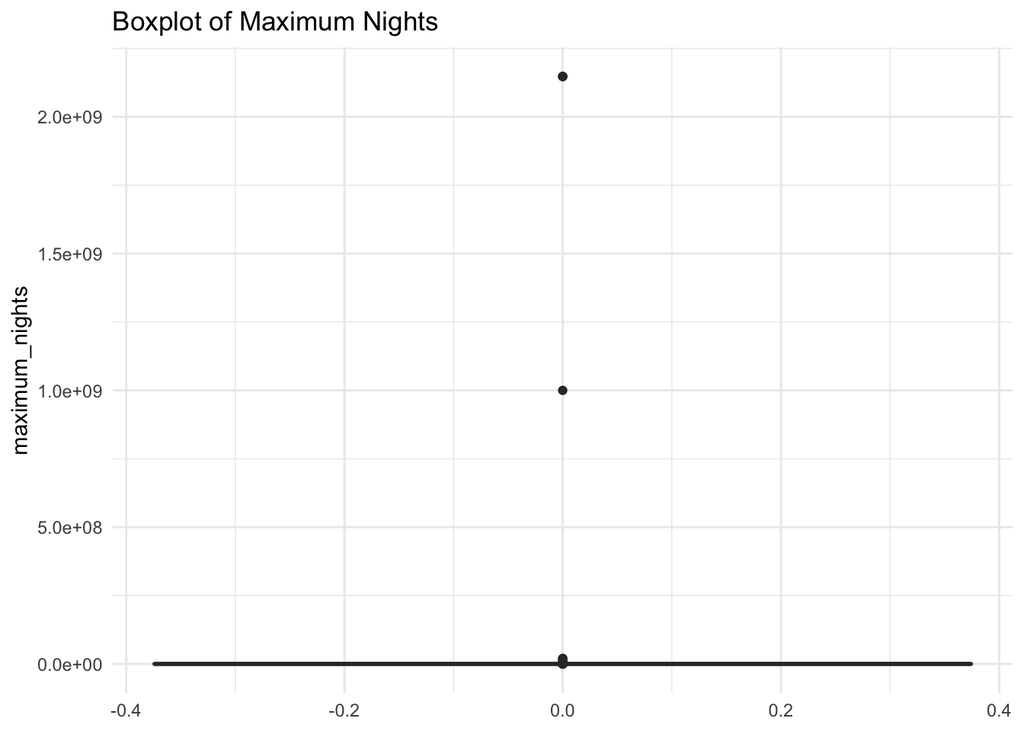

```r
# Boxplot of maximum_nights

ggplot(cleaned_data, aes(y = maximum_nights)) +
  geom_boxplot() +
  labs(title = "Boxplot of Maximum Nights") +
  theme_minimal()
```

Looking at the box plot, there are extreme outliers in the maximum nights.

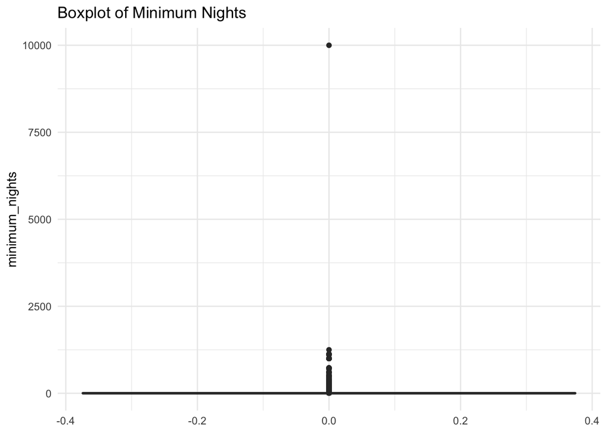

```r
ggplot(cleaned_data, aes(y = minimum_nights)) +
  geom_boxplot() +
  labs(title = "Boxplot of Minimum Nights") +
  theme_minimal()
```

Minimum nights have outliers too

The below is a line plot of the same graph to understand the outliers.

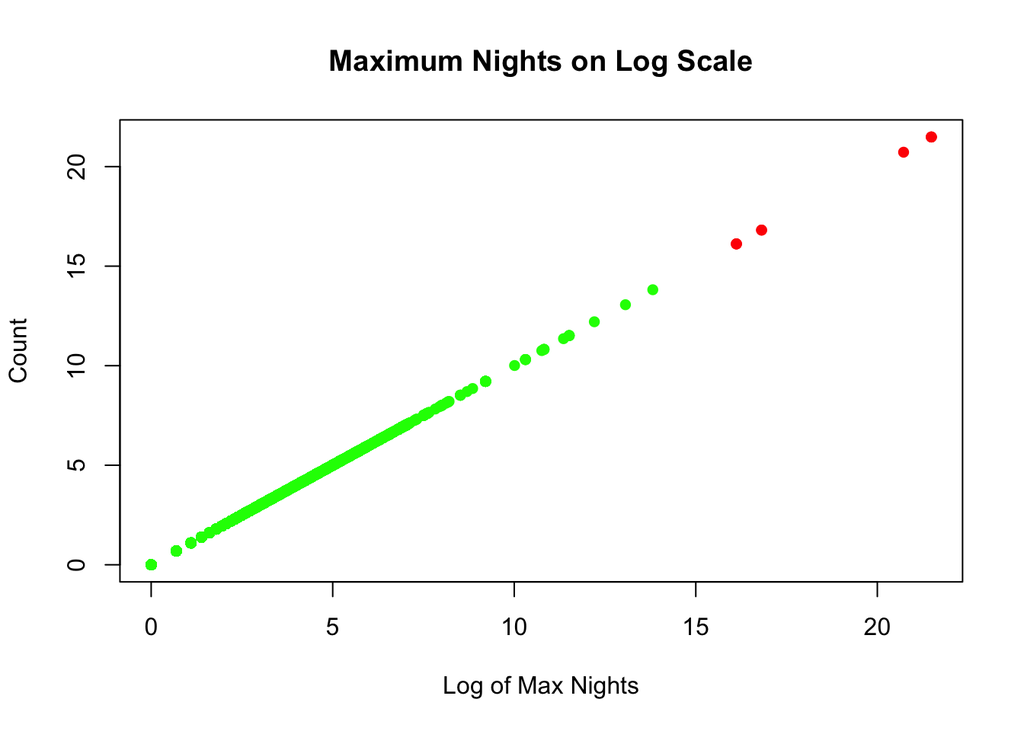

```r
# Transform maximum_nights to log scale and plot it
cleaned_data$log_max_nights <- log(cleaned_data$maximum_nights)
colors <- ifelse(cleaned_data$log_max_nights < 15, "green", "red")

plot(cleaned_data$log_max_nights, cleaned_data$log_max_nights,
     main = "Maximum Nights on Log Scale",
     xlab = "Log of Max Nights",
     ylab = "Count",
     col = colors,
     pch = 16)
```

We compute the same chart for ameneties and number of bedrooms

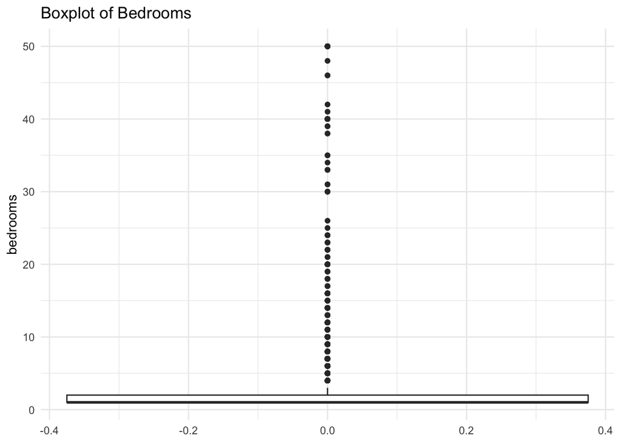

```r
# Boxplot of bedrooms and amenities
ggplot(cleaned_data, aes(y = bedrooms)) +
  geom_boxplot() +
  labs(title = "Boxplot of Bedrooms") +
  theme_minimal()
```

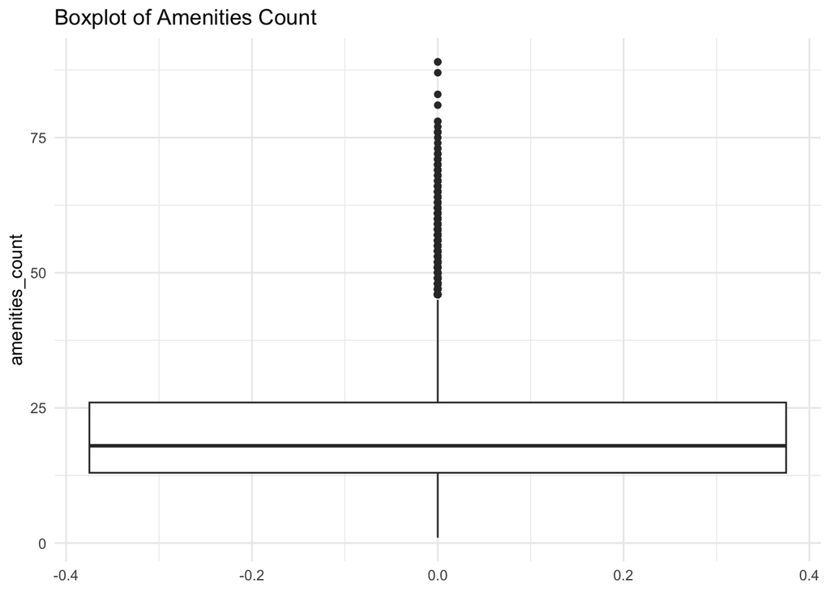

```r
ggplot(cleaned_data, aes(y = amenities_count)) +
  geom_boxplot() +
  labs(title = "Boxplot of Amenities Count") +
  theme_minimal()
```

# Correlation matrix

```r
correlation_matrix <- round(cor(numeric_vars), 2)
correlation_matrix
```

```
##                 accommodates bedrooms price minimum_nights maximum_nights
## accommodates            1.00     0.64  0.15          -0.03              0
## bedrooms                0.64     1.00  0.14          -0.01              0
## price                   0.15     0.14  1.00           0.01              0
## minimum_nights         -0.03    -0.01  0.01           1.00              0
## maximum_nights          0.00     0.00  0.00           0.00              1
## log_price               0.36     0.31  0.36          -0.02              0
## amenities_count         0.22     0.14  0.03          -0.03              0
##                 log_price amenities_count
## accommodates         0.36            0.22
## bedrooms             0.31            0.14
## price                0.36            0.03
## minimum_nights      -0.02           -0.03
## maximum_nights       0.00            0.00
## log_price            1.00            0.13
## amenities_count      0.13            1.00
```

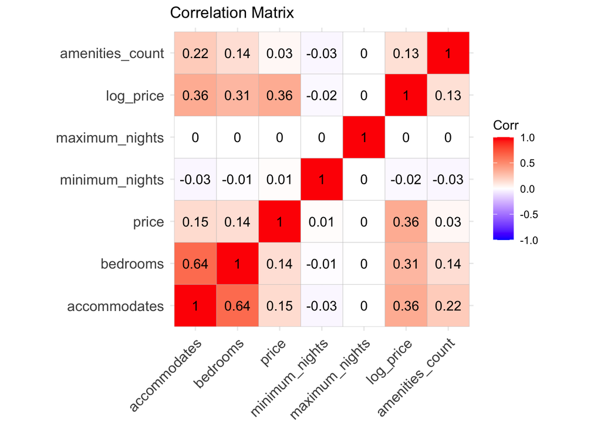

```r
ggcorrplot(correlation_matrix, lab = TRUE, title = "Correlation Matrix")
```

# Interquartile cleaning and removal of outliers.

```r
q1_accom <- quantile(cleaned_data$accommodates, 0.25)
q3_accom <- quantile(cleaned_data$accommodates, 0.75)
iqr_accom <- q3_accom - q1_accom
lower_accom <- q1_accom - 1.5 * iqr_accom
upper_accom <- q3_accom + 1.5 * iqr_accom



q1_bedrooms <- quantile(cleaned_data$bedrooms, 0.25)
q3_bedrooms <- quantile(cleaned_data$bedrooms, 0.75)
iqr_bedrooms <- q3_bedrooms - q1_bedrooms
lower_bedroom <- q1_bedrooms - 1.5 * iqr_bedrooms
upper_bedroom <- q3_bedrooms + 1.5 * iqr_bedrooms



q1_minimum_nights <- quantile(cleaned_data$minimum_nights, 0.25)
q3_minimum_nights <- quantile(cleaned_data$minimum_nights, 0.75)
iqr_minimum_nights <- q3_minimum_nights - q1_minimum_nights
lower_min_night <- q1_minimum_nights - 1.5 * iqr_minimum_nights
upper_min_night <- q3_minimum_nights + 1.5 * iqr_minimum_nights



q1_maximum_nights <- quantile(cleaned_data$maximum_nights, 0.25)
q3_maximum_nights <- quantile(cleaned_data$maximum_nights, 0.75)
iqr_maximum_nights <- q3_maximum_nights - q1_maximum_nights
lower_max_night <- q1_maximum_nights - 1.5 * iqr_maximum_nights
upper_max_night <- q3_maximum_nights + 1.5 * iqr_maximum_nights




cleaned_data <- cleaned_data %>%
  filter(accommodates >= lower_accom & accommodates <= upper_accom)

cleaned_data <- cleaned_data %>%
  filter(minimum_nights >= lower_min_night & minimum_nights <= upper_min_night)

cleaned_data <- cleaned_data %>%
  filter(q1_maximum_nights >= lower_max_night & q1_maximum_nights <= upper_max_night)




cleaned_data <- cleaned_data[cleaned_data$maximum_nights < 1500, ]

cleaned_data <- cleaned_data %>%
  mutate(
    room_type = as.factor(room_type),
    instant_bookable = as.factor(instant_bookable),
    host_has_profile_pic = as.factor(host_has_profile_pic),
    host_identity_verified = as.factor(host_identity_verified),
    city = as.factor(city)
  )
```

Looking at the accommodation and average log price. There appears to be a increase in price as the accommodation increases.

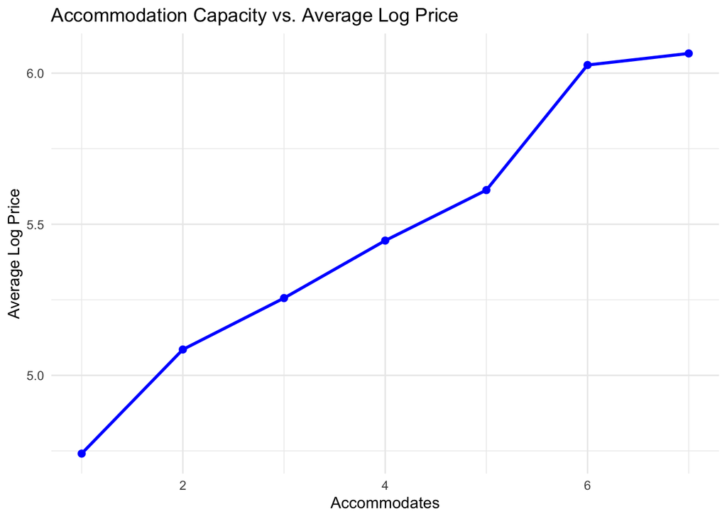

```r
avg_log_price <- cleaned_data %>%
  group_by(accommodates) %>%
  summarise(mean_log_price = mean(log_price, na.rm = TRUE))
# Line graph for accommodation capacity vs. average log price
ggplot(avg_log_price, aes(x = accommodates, y = mean_log_price)) +
  geom_line(color = "blue", size = 1) +
  geom_point(color = "blue", size = 2) +  # Adding points to highlight each accommodates level
  labs(
    title = "Accommodation Capacity vs. Average Log Price",
    x = "Accommodates",
    y = "Average Log Price"
  ) +
  theme_minimal()
```

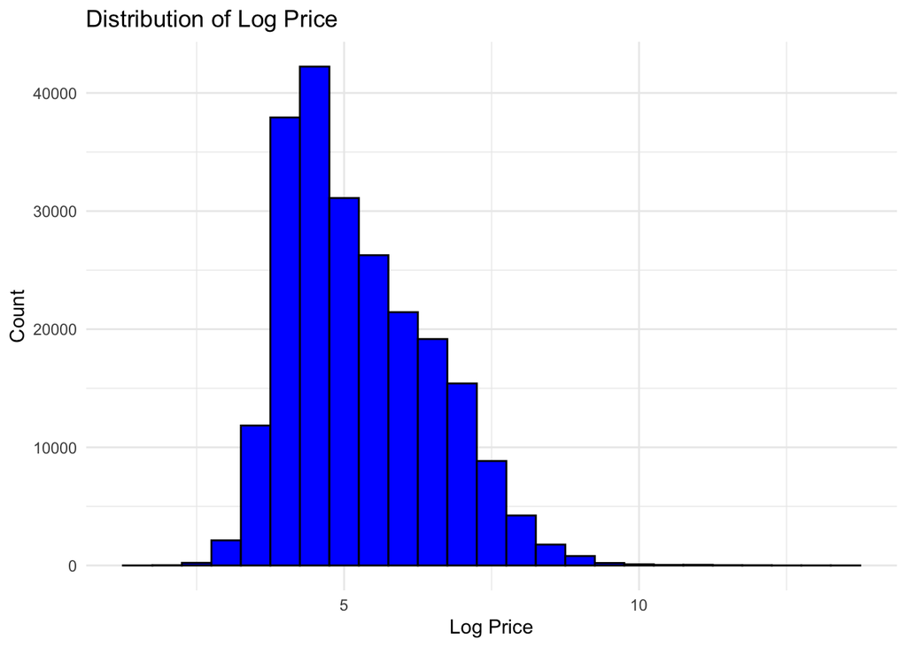

```r
# Plotting histogram for the count of log price
ggplot(cleaned_data, aes(x = log_price)) +
  geom_histogram(binwidth = 0.5, fill = "blue", color = "black") +
  labs(
    title = "Distribution of Log Price",
    x = "Log Price",
    y = "Count"
  ) +
  theme_minimal()
```

# Splitting the dataset

```r
set.seed(123)
# Create a random sample of row indices for the training set
train_indices1 <- sample(1:nrow(cleaned_data), size = 0.8 * nrow(cleaned_data))

# Split the data
train_set1 <- cleaned_data[train_indices1, ]  # 80%
test_set1 <- cleaned_data[-train_indices1, ]  # 20%
```

# Linear model with all the significant variables

```r
model_lm <- lm(log_price ~ . - price - amenities_count - log_max_nights, data = train_set1 )

summary(model_lm)
```

```
##
## Call:
## lm(formula = log_price ~ . - price - amenities_count - log_max_nights,
##     data = train_set1)
##
## Residuals:
##     Min      1Q  Median      3Q     Max
## -5.6879 -0.3931 -0.0648  0.3096  8.1054
##
## Coefficients:
##                              Estimate Std. Error  t value Pr(>|t|)
## (Intercept)                 6.789e+00  2.781e-02  244.137  < 2e-16 ***
## room_typeHotel room         3.108e-01  9.892e-03   31.421  < 2e-16 ***
## room_typePrivate room      -2.787e-01  3.858e-03  -72.245  < 2e-16 ***
## room_typeShared room       -6.952e-01  1.204e-02  -57.765  < 2e-16 ***
## accommodates                1.672e-01  1.324e-03  126.274  < 2e-16 ***
## bedrooms                    1.107e-01  2.117e-03   52.289  < 2e-16 ***
## instant_bookableTrue       -5.878e-03  3.097e-03   -1.898   0.0577 .
## host_has_profile_picTrue   -1.980e-01  2.671e-02   -7.413 1.24e-13 ***
## host_identity_verifiedTrue -3.937e-02  3.331e-03  -11.820  < 2e-16 ***
## minimum_nights              5.131e-03  8.663e-04    5.923 3.17e-09 ***
## maximum_nights              4.231e-05  2.888e-06   14.651  < 2e-16 ***
## cityCape Town              -2.777e-01  7.996e-03  -34.725  < 2e-16 ***
## cityHong Kong              -7.662e-01  1.232e-02  -62.206  < 2e-16 ***
## cityIstanbul               -1.534e+00  7.407e-03 -207.057  < 2e-16 ***
## cityMexico City            -5.496e-01  7.753e-03  -70.891  < 2e-16 ***
## cityNew York               -2.484e+00  8.886e-03 -279.584  < 2e-16 ***
## cityParis                  -2.760e+00  6.608e-03 -417.646  < 2e-16 ***
## cityRio de Janeiro         -1.627e+00  7.496e-03 -217.074  < 2e-16 ***
## cityRome                   -3.025e+00  7.287e-03 -415.164  < 2e-16 ***
## citySydney                 -2.311e+00  7.170e-03 -322.234  < 2e-16 ***
## ---
## Signif. codes:  0 '***' 0.001 '**' 0.01 '*' 0.05 '.' 0.1 ' ' 1
##
## Residual standard error: 0.6251 on 179068 degrees of freedom
## Multiple R-squared:  0.7401, Adjusted R-squared:  0.7401
## F-statistic: 2.684e+04 on 19 and 179068 DF,  p-value: < 2.2e-16
```

```r
# Remove rows where the column contains 42 or 46 as the factor will affect testing the
#test_data2 <- test_set1 %>%
 # filter(!(bedrooms %in% c(42, 46, 18, 38)))


predicted_values <- predict(model_lm, newdata = test_set1)


accuracy(model_lm$fitted.values, test_set1$log_price)
```

```
##                   ME    RMSE      MAE       MPE    MAPE
## Test set 0.005517297 1.61569 1.284826 -5.144567 24.9804
```

# step wise model

```r
# Apply stepwise selection
model_stepwise <- step(model_lm, direction = "both")
```

```
## Start:  AIC=-168257.9
## log_price ~ (room_type + accommodates + bedrooms + price + instant_bookable +
##     host_has_profile_pic + host_identity_verified + minimum_nights +
##     maximum_nights + city + amenities_count + log_max_nights) -
##     price - amenities_count - log_max_nights
##
##                          Df Sum of Sq    RSS     AIC
## <none>                                 69974 -168258
## - instant_bookable        1         1  69976 -168256
## - minimum_nights          1        14  69988 -168225
## - host_has_profile_pic    1        21  69996 -168205
## - host_identity_verified  1        55  70029 -168120
## - maximum_nights          1        84  70058 -168045
## - bedrooms                1      1068  71043 -165546
## - room_type               3      3690  73664 -159060
## - accommodates            1      6231  76205 -152983
## - city                    9    170891 240866   53097
```

```r
# Model summary and accuracy evaluation
summary(model_stepwise)
```

```
##
## Call:
## lm(formula = log_price ~ (room_type + accommodates + bedrooms +
##     price + instant_bookable + host_has_profile_pic + host_identity_verified +
##     minimum_nights + maximum_nights + city + amenities_count +
##     log_max_nights) - price - amenities_count - log_max_nights,
##     data = train_set1)
##
## Residuals:
##     Min      1Q  Median      3Q     Max
## -5.6879 -0.3931 -0.0648  0.3096  8.1054
##
## Coefficients:
##                              Estimate Std. Error  t value Pr(>|t|)
## (Intercept)                 6.789e+00  2.781e-02  244.137  < 2e-16 ***
## room_typeHotel room         3.108e-01  9.892e-03   31.421  < 2e-16 ***
## room_typePrivate room      -2.787e-01  3.858e-03  -72.245  < 2e-16 ***
## room_typeShared room       -6.952e-01  1.204e-02  -57.765  < 2e-16 ***
## accommodates                1.672e-01  1.324e-03  126.274  < 2e-16 ***
## bedrooms                    1.107e-01  2.117e-03   52.289  < 2e-16 ***
## instant_bookableTrue       -5.878e-03  3.097e-03   -1.898   0.0577 .
## host_has_profile_picTrue   -1.980e-01  2.671e-02   -7.413 1.24e-13 ***
## host_identity_verifiedTrue -3.937e-02  3.331e-03  -11.820  < 2e-16 ***
## minimum_nights              5.131e-03  8.663e-04    5.923 3.17e-09 ***
## maximum_nights              4.231e-05  2.888e-06   14.651  < 2e-16 ***
## cityCape Town              -2.777e-01  7.996e-03  -34.725  < 2e-16 ***
## cityHong Kong              -7.662e-01  1.232e-02  -62.206  < 2e-16 ***
## cityIstanbul               -1.534e+00  7.407e-03 -207.057  < 2e-16 ***
## cityMexico City            -5.496e-01  7.753e-03  -70.891  < 2e-16 ***
## cityNew York               -2.484e+00  8.886e-03 -279.584  < 2e-16 ***
## cityParis                  -2.760e+00  6.608e-03 -417.646  < 2e-16 ***
## cityRio de Janeiro         -1.627e+00  7.496e-03 -217.074  < 2e-16 ***
## cityRome                   -3.025e+00  7.287e-03 -415.164  < 2e-16 ***
## citySydney                 -2.311e+00  7.170e-03 -322.234  < 2e-16 ***
## ---
## Signif. codes:  0 '***' 0.001 '**' 0.01 '*' 0.05 '.' 0.1 ' ' 1
##
## Residual standard error: 0.6251 on 179068 degrees of freedom
## Multiple R-squared:  0.7401, Adjusted R-squared:  0.7401
## F-statistic: 2.684e+04 on 19 and 179068 DF,  p-value: < 2.2e-16
```

```r
#accuracy(model_stepwise$fitted.values, test_set1$log_price)
predicted_values1 <- predict(model_stepwise, newdata = test_set1)

accuracy(predicted_values1, test_set1$log_price)
```

```
##                    ME      RMSE       MAE       MPE     MAPE
## Test set -0.001045605 0.6221634 0.4576997 -1.336628 8.779183
```

# Model without instant bookable and host_identity_verified and host_has_profile_pic

```r
model_lm111 <- lm(log_price ~ .- price - amenities_count - log_max_nights - instant_bookable - host_identity_verified - host_has_profile_pic, data = train_set1 )

summary(model_lm111)
```

```
##
## Call:
## lm(formula = log_price ~ . - price - amenities_count - log_max_nights -
##     instant_bookable - host_identity_verified - host_has_profile_pic,
##     data = train_set1)
##
## Residuals:
##     Min      1Q  Median      3Q     Max
## -5.7126 -0.3914 -0.0650  0.3074  8.1204
##
## Coefficients:
##                         Estimate Std. Error  t value Pr(>|t|)
## (Intercept)            6.562e+00  7.842e-03  836.754  < 2e-16 ***
## room_typeHotel room    3.090e-01  9.820e-03   31.464  < 2e-16 ***
## room_typePrivate room -2.747e-01  3.845e-03  -71.443  < 2e-16 ***
## room_typeShared room  -6.889e-01  1.203e-02  -57.267  < 2e-16 ***
## accommodates           1.665e-01  1.323e-03  125.791  < 2e-16 ***
## bedrooms               1.116e-01  2.117e-03   52.718  < 2e-16 ***
## minimum_nights         5.589e-03  8.626e-04    6.479 9.27e-11 ***
## maximum_nights         4.173e-05  2.889e-06   14.441  < 2e-16 ***
## cityCape Town         -2.774e-01  7.991e-03  -34.716  < 2e-16 ***
## cityHong Kong         -7.688e-01  1.231e-02  -62.451  < 2e-16 ***
## cityIstanbul          -1.532e+00  7.408e-03 -206.775  < 2e-16 ***
## cityMexico City       -5.537e-01  7.744e-03  -71.496  < 2e-16 ***
## cityNew York          -2.491e+00  8.845e-03 -281.606  < 2e-16 ***
## cityParis             -2.762e+00  6.555e-03 -421.420  < 2e-16 ***
## cityRio de Janeiro    -1.625e+00  7.467e-03 -217.672  < 2e-16 ***
## cityRome              -3.030e+00  7.280e-03 -416.175  < 2e-16 ***
## citySydney            -2.314e+00  7.138e-03 -324.197  < 2e-16 ***
## ---
## Signif. codes:  0 '***' 0.001 '**' 0.01 '*' 0.05 '.' 0.1 ' ' 1
##
## Residual standard error: 0.6255 on 179071 degrees of freedom
## Multiple R-squared:  0.7398, Adjusted R-squared:  0.7398
## F-statistic: 3.182e+04 on 16 and 179071 DF,  p-value: < 2.2e-16
```

```r
accuracy(model_lm111$fitted.values, test_set1$log_price)
```

```
##                  ME     RMSE      MAE       MPE    MAPE
## Test set 0.00545553 1.615619 1.284715 -5.146257 24.9776
```

# Baseline

```r
predictions = predict(model_lm111, newdata=test_set1)

#compute common accuracy measures for the model
library(forecast)
accuracy(predictions, test_set1$log_price)
```

```
##                    ME      RMSE      MAE       MPE     MAPE
## Test set -0.001032874 0.6223893 0.457815 -1.338401 8.780218
```

```r
# Calculate the baseline predictions (average prediction)dataset
mean_rating_train = mean(test_set1$log_price)
baseline_predictions = rep(mean_rating_train, length(predictions))


accuracy(baseline_predictions, test_set1$log_price)
```

```
##                    ME     RMSE      MAE       MPE     MAPE
## Test set 3.446403e-15 1.222363 1.014218 -5.254228 19.87895
```

# Random forest

```r
library(randomForest)
model.rf = randomForest(log_price ~ .- price - amenities_count - log_max_nights - instant_bookable, data = train_set1, ntree=20,
nodesize=25, importance = TRUE)


library(caret)

predict_class.rf = predict(model.rf, newdata = test_set1)
predict_class.rf <- factor(predict_class.rf)
#test_set1$log_price <- factor(test_set1$log_price)
predict_class.rf <- factor(predict_class.rf, levels = levels(test_set1$log_price))

predicted_values <- predict(model.rf, newdata = test_set1)
actual_values <- test_set1$log_price
library(Metrics)
```

```r
#rmse(actual_values, predicted_values)

ME <- mean(actual_values - predicted_values)

RMSE <- sqrt(mean((actual_values - predicted_values)^2))

MAE <- mean(abs(actual_values - predicted_values))

MPE <- mean((actual_values - predicted_values) / actual_values) * 100


MAPE <- mean(abs((actual_values - predicted_values) / actual_values)) * 100
```

```r
ME
```

```
## [1] 0.001765735
```

```r
RMSE
```

```
## [1] 0.6077106
```

```r
MAE
```

```
## [1] 0.447491
```

```r
MPE
```

```
## [1] -1.594786
```

```r
MAPE
```

```
## [1] 8.692659
```